# Econometria II

Mestrado em Administração  
Aula 3

Prof. Washington Santos da Silva

IFMG - Campus Formiga

18 de março de 2026

## Na Aula 2

**Tópicos Abordados**

- Parte 1
  - Modelo Estático de Regressão com Séries Temporais
  - Testes para Autocorrelação nos Resíduos de um Modelo de Regressão
  - Modelos Dinâmicos de Regressão com Séries Temporais
  - Convivendo com Autocorrelação
- Parte 2
  - Leitura/Estudo do Relatório:
  - Vocês deverão trabalhar na Lista 1 de exercícios.

## Nesta Aula

**Tópicos**

- Estacionariedade
- Processo Ruído Branco
- Processo Autorregressivo
- Processo de Médias Móveis
- Processo Autorregressivo de Médias Móveis
- FAC e FACP de Processos AR, MA e ARMA
- Metodologia de Box e Jenkins (1970)

## Série dos Exemplos

**Descrição**

- Em alguns exemplos, utilizaremos a série trimestral de lucro por ação da Johnson & Johnson.
- A série possui 84 observações trimestrais (21 anos), do primeiro trimestre de 1960 ao último trimestre de 1980.
- A série está disponível no pacote `astsa`.
- Uma etapa inicial importante na análise de uma série temporal é construir o gráfico da série.

## Série dos Exemplos

```r
# carrega o pacote astsa
library(astsa)

# jj é a série trimestral de lucro por ação da Johnson & Johnson
# tsplot() é uma função do pacote astsa para visualizar séries temporais
tsplot(jj,
       type = "o",
       ylab = "Lucro por Ação",
       xlab = "Trimestre")
```

## Série dos Exemplos

[figure not shown]

## Série dos Exemplos

**Inspeção visual**

- A série apresenta clara tendência de crescimento ao longo do período, aparentemente de forma exponencial.
- Além disso, observa-se um padrão sazonal, com amplitude crescente ao longo do tempo.
- Esse comportamento sugere que a variabilidade da série aumenta com o nível da própria série.

# Estacionariedade

## Duas Classes Gerais de Processos

**Definição**

- Processos Estocásticos **Estacionários**
- Processos Estocáticos **Não Estacionários**

## Processo Estritamente Estacionário

**Definição**

Uma processo **estritamente estacionário** é aquele para o qual a distribuição conjunta de probabilidade de cada coleção de VAs é a mesma do conjunto deslocado no tempo:

$$\begin{aligned}
P\{y_{t_1} \leq b_1,\ldots,y_{t_n}\leq b_n\}=P\{y_{t_1+m} \leq b_1,\ldots,y_{t_n+m}\leq b_n\}
\end{aligned}$$

## Processo Fracamente Estacionário

**Descrição**

Se um processo (ou série temporal) satisfaz as três condições a seguir, diz-se que ele é **fracamente estacionário** (ou estacionário em covariância)

$$\begin{aligned}
E(y_{t}) &= \mu \quad t=1,2,\ldots,\infty \\
E(y_t-\mu)(y_t-\mu) &= \sigma^2<\infty \\
E(y_{t_1}-\mu)(y_{t_2}-\mu) &= \gamma _{t_2-t_1 }\quad\forall\, t_{1},t_{2}
\end{aligned}$$

- Assim, se o processo é estacionário em covariância, todas as variâncias são iguais e todas as covariâncias dependem da diferença entre $t_1$ e $t_2$.

## Quiz 1

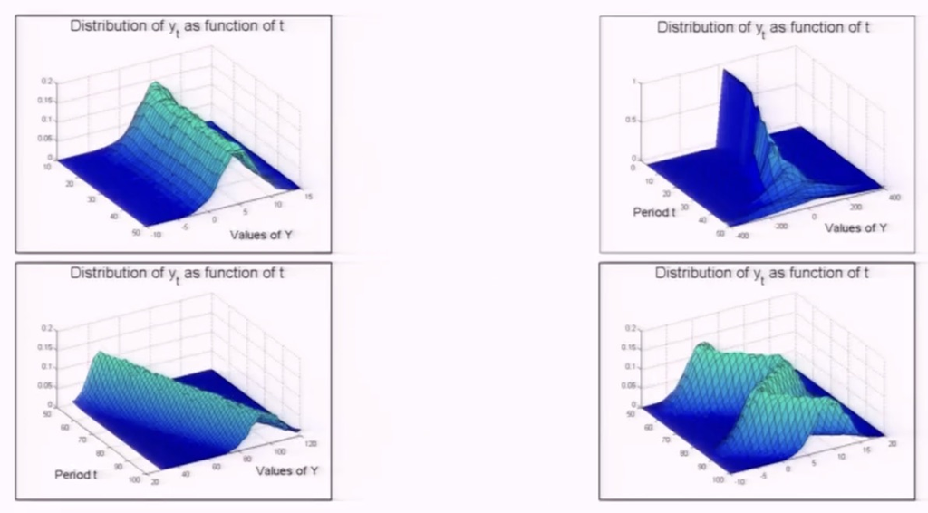

Quais Processos são Estacionários? Quais são Não Estacionários?

## Função de Autocovariância

**Caso Geral**

Para um processo estocástico $\{y_t\}$, a função de autocovariância é definida por

$$\gamma(t,s)=\operatorname{Cov}(y_t,y_s)
=E\big[(y_t-E(y_t))(y_s-E(y_s))\big].$$

- A função de autocovariância mede a **dependência linear** entre os valores da série em dois instantes de tempo.
- Em particular, ela indica como os desvios de $y_t$ e $y_s$ em relação às suas respectivas médias variam conjuntamente.
- No caso geral, a autocovariância pode depender dos dois instantes de tempo, $t$ e $s$.
- Se o processo for fracamente estacionário, então a autocovariância depende apenas da defasagem entre os períodos.
- Nesse caso, escrevemos

$$\gamma_h=\operatorname{Cov}(y_t,y_{t-h})
=E\big[(y_t-E(y_t))(y_{t-h}-E(y_{t-h}))\big],
\qquad h=0,1,2,\ldots$$

## Função de Autocovariância em R

```r
# função de autocovariância amostral
facov <- acf(jj, type = "covariance", plot = FALSE)
# extrai as autocovariâncias amostrais
facov$acf
```

```
#> , , 1
#>
#>            [,1]
#>  [1,] 18.354881
#>  [2,] 16.980139
#>  [3,] 16.303963
#>  [4,] 15.286826
#>  [5,] 15.125835
#>  [6,] 14.019455
#>  [7,] 13.171366
#>  [8,] 12.389988
#>  [9,] 12.010620
#> [10,] 11.165917
#> [11,] 10.354938
#> [12,]  9.646597
#> [13,]  9.185034
#> [14,]  8.370752
#> [15,]  7.757765
#> [16,]  7.163787
#> [17,]  6.790041
#> [18,]  6.135259
#> [19,]  5.628100
#> [20,]  5.099720
```

```r
# gama(0) = var(jj)
var(jj) * (length(jj) - 1) / length(jj)
```

```
#> [1] 18.35488
```

## Função de Autocorrelação

**Descrição**

- No entanto, o valor das autocovariâncias depende das unidades de medida de $y_t$.
- Portanto, é mais conveniente usar as **autocorrelações**, que são as autocovariâncias normalizadas pela divisão pela variância:

$$\begin{aligned}
\tau_s=\frac{\gamma_s}{\gamma_0},\quad s=0,1,2,\ldots
\end{aligned}$$

- O gráfico de $\tau_s$ em função de $s = 0,1,2,\ldots$, obtemos a **função de autocorrelação** (ou correlograma).

## Função de Autocorrelação em R

```r
# função de autocorrelação amostral
facor <- acf(jj, plot = FALSE)
# extrai as autocorrelações amostrais
facor$acf
```

```
#> , , 1
#>
#>            [,1]
#>  [1,] 1.0000000
#>  [2,] 0.9251021
#>  [3,] 0.8882631
#>  [4,] 0.8328480
#>  [5,] 0.8240770
#>  [6,] 0.7637998
#>  [7,] 0.7175947
#>  [8,] 0.6750242
#>  [9,] 0.6543557
#> [10,] 0.6083350
#> [11,] 0.5641518
#> [12,] 0.5255603
#> [13,] 0.5004137
#> [14,] 0.4560505
#> [15,] 0.4226541
#> [16,] 0.3902933
#> [17,] 0.3699311
#> [18,] 0.3342576
#> [19,] 0.3066269
#> [20,] 0.2778400
```

## Dependência Temporal

**Motivação para Modelagem**

- Na análise de séries temporais, o objetivo é modelar a dependência temporal entre observações, isto é, a estrutura de autocovariância (ou autocorrelação), que caracteriza a série temporal, visto que:
- Observações sucessivas tendem a apresentar dependência (correlação) temporal.
- Em processos estacionários, essa dependência depende apenas da defasagem entre os períodos.

## Processos Básicos

**Processos AR, MA e ARMA**

- Os modelos básicos lineares de séries temporais procuram captuar essa estrutura de dependência temporal, os principais são:
- Processo Ruído Branco
- Processos Autorregressivos (AR)
- Processos de Médias Móveis (MA)
- Processos Autorregressivos de Médias Móveis (ARMA)

# Processo Ruído Branco

## Processo Ruído Branco

**Definição**

Seja $\{\varepsilon_t\}$ um processo estocástico, diremos que $\{\varepsilon_t\}$ é um processo **ruído branco não correlacionado** se:

1. $E(\varepsilon_t)=0$, para todo $t$;
2. $V(\varepsilon_t)=\sigma^2<\infty$, para todo $t$;
3. $$\gamma_k=\operatorname{Cov}(\varepsilon_t,\varepsilon_{t-k})=
   \begin{cases}
   \sigma^2, & \text{se } k=0,\\
   0, & \text{se } k\neq 0.
   \end{cases}$$

Portanto, um processo ruído branco não correlacionado possui:

- média constante igual a zero;
- variância constante e finita;
- autocovariâncias nulas em todas as defasagens não nulas.

Trata-se de um processo sem autocorrelação serial.

## Processo Ruído Branco

**Classificações**

A hipótese de independência no tempo é mais forte do que a de ausência de autocorrelação serial. Se $\{\varepsilon_t\}$ satisfaz as condições (1)–(3) e, além disso,

4. $\varepsilon_t$ e $\varepsilon_s$ são independentes para $t \neq s$,

então $\{\varepsilon_t\}$ é um processo **ruído branco independente**.

Se, adicionalmente, $\{\varepsilon_t\}$ é um processo gaussiano, então $\{\varepsilon_t\}$ é um processo de **ruído branco gaussiano**.

Equivalentemente, nesse caso, toda distribuição marginal é normal:
$$\varepsilon_t \sim N(0,\sigma^2), \quad \text{para todo } t.$$

Assim:

- todo ruído branco independente é não correlacionado;
- todo ruído branco gaussiano é independente;
- a recíproca, em geral, não é verdadeira.

## Ruído Branco Independente Não Gaussiano

```r
# fixa a semente
set.seed(123)

# número de observações
n <- 100

# ruído branco independente não gaussiano
ruido_branco_uniforme <- runif(n, min = -1, max = 1)

# visualização
plot(
  ruido_branco_uniforme,
  type = "l",
  main = "Ruído Branco Independente Não Gaussiano",
  ylab = "y",
  xlab = "Tempo"
)

abline(h = 0, col = "blue", lty = 2)
```

## Ruído Branco Independente Não Gaussiano

[figure not shown]

Exemplo de ruído branco independente com distribuição uniforme.

## Ruído Branco Gaussiano

```r
# fixa a semente
set.seed(123)

# ruído branco gaussiano
ruido_branco_gaussiano <- rnorm(n, mean = 0, sd = 1)

# visualização
plot(
  ruido_branco_gaussiano,
  type = "l",
  main = "Ruído Branco Gaussiano",
  ylab = "y",
  xlab = "Tempo"
)

abline(h = 0, col = "red", lty = 2)
```

## Ruído Branco Gaussiano

[figure not shown]

Exemplo de ruído branco gaussiano.

## Um Processo Ruído Branco

**Definição**

- Pela def., a função de autocorrelação de um processo ruído branco será zero, exceto por um único pico igual a 1 em $s=0$.
- $\hat{\tau}_s \sim \, \text{aprox}\, N(0,1/T)$, em que $T =$ tamanho da amostra.
- Podemos usar isso para realizar **testes de significância** dos **coeficientes de autocorrelação**, construindo um intervalo de confiança.
- Por exemplo, um intervalo de confiança de 95% é dado por
  $$\pm 1.96\times\displaystyle\frac{1}{\sqrt T}$$
- Se o coeficiente de autocorrelação amostral, $\hat{\tau}_s$, ficar fora dessa região para algum valor de $s$, rejeitamos a hipótese nula de que o verdadeiro valor do coeficiente na defasagem $s$ é zero.

## Função de Autocorrelação Amostral (FAC)

```r
# função de autocorrelação amostral em R
acf(ruido_branco_gaussiano)
```

[figure not shown]

A linha azul pontilhada mostra o intervalo de confiança de 95% para os coeficientes de autocorrelação.

## Testes de Hipóteses Conjuntas

**Teste de Box-Pierce**

- Também podemos testar a hipótese conjunta de que todos os $m$ coeficientes de correlação $\tau_k$ são simultaneamente iguais a zero, usando a estatística $Q$ desenvolvida por Box e Pierce:

$$Q = T\sum\limits_{k=1}^m{\hat{\tau}_k^2}$$

em que $T =$ tamanho da amostra, $m =$ defasagem máxima

- A estatística $Q$ é assintoticamente distribuída como uma $\chi_m^2$.

## Teste de Box-Pierce em R

```r
# teste de Box-Pierce
Box.test(ruido_branco_gaussiano, type = "Box-Pierce")
```

```
#>
#>  Box-Pierce test
#>
#> data:  ruido_branco_gaussiano
#> X-squared = 0.065517, df = 1, p-value = 0.798
```

**Resultado**

Como esperado, o resultado do teste de Box-Pierce (valor-p $\gg$ 0.05) **não** fornece evidências para rejeitar a hipótese nula de que todos os coeficeintes de autocorrelação são zero.

## Testes de Hipóteses Conjuntas

**Teste de Ljung-Box**

- No entanto, o teste de Box-Pierce apresenta propriedades fracas em pequenas amostras, por isso foi desenvolvida uma variante, chamada estatística de Ljung-Box:

$$Q^\ast = T(T+2)\sum\limits_{k=1}^m{\frac{\hat{\tau}_k^2}{T-k}}\sim\chi_m^2$$

- Essa estatística é muito útil como teste portmanteau (geral) de dependência linear em séries temporais.

## Teste de Lyung-Box em R

```r
# teste de Ljung-Box
Box.test(ruido_branco_gaussiano, type = "Ljung-Box")
```

```
#>
#>  Box-Ljung test
#>
#> data:  ruido_branco_gaussiano
#> X-squared = 0.067503, df = 1, p-value = 0.795
```

**Resultado**

Novamente, como esperado, o resultado do teste de Ljung-Box (valor-p $\gg$ 0.05) **não** fornece evidências para rejeitar a hipótese nula de que todos os coeficeintes de autocorrelação são zero.

# Processo Autorregressivo

## Processo Autorregressivo - AR(p)

**Definição**

- Um modelo autorregressivo de ordem $p$, AR($p$), é dado por

$$y_t = c + \phi_1 y_{t-1} + \phi_2 y_{t-2} + \cdots + \phi_p y_{t-p} + u_t,
\qquad
u_t \sim WN(0,\sigma_u^2).$$

- Em notação de somatório:

$$y_t = c + \sum_{i=1}^{p}\phi_i y_{t-i} + u_t.$$

- Usando o operador de defasagem $L$, com $Ly_t = y_{t-1}$, temos:

$$\phi(L)y_t = c + u_t,$$

em que

$$\phi(L)=1-\phi_1L-\phi_2L^2-\cdots-\phi_pL^p.$$

## Processo AR(p)

**Média = $E(y_t)$ - Derivação sob Estacionariedade**

- **Se o processo for estacionário**, sua média é constante ao longo do tempo:

$$E(y_t) = E(y_{t-1}) = \cdots =\mu.$$

- Tomando o valor esperado no modelo AR(p):

$$E(y_t)=c+\phi_1E(y_{t-1})+\phi_2E(y_{t-2})+\cdots+\phi_pE(y_{t-p})+E(u_t).$$

- Como $E(u_t)=0$, segue que:

$$\mu = c+\phi_1\mu+\phi_2\mu+\cdots+\phi_p\mu.$$

- Portanto:

$$\mu\bigl(1-\phi_1-\phi_2-\cdots-\phi_p\bigr)=c,$$

e assim:

$$\mu = E(y_t) = \frac{c}{1 - \phi_1 - \phi_2 - \cdots -\phi_p}.$$

## Processo Autorregressivo - AR(p)

**Momentos do Processo**

- Vimos que se o processo AR(p) for fracamente estacionário, então

$$E(y_t)=\mu=\frac{c}{1-\phi_1-\phi_2-\cdots-\phi_p}.$$

- As **autocovariâncias** e **autocorrelações** são obtidas a partir das equações de Yule-Walker.

$$\begin{aligned}
\tau_1 &= \phi_1 + \phi_2\tau_1 + \cdots + \phi_p\tau_{p-1}, \\
\tau_2 &= \phi_1\tau_1 + \phi_2 + \cdots + \phi_p\tau_{p-2}, \\
&\;\vdots \\
\tau_p &= \phi_1\tau_{p-1} + \phi_2\tau_{p-2} + \cdots + \phi_p.
\end{aligned}$$

- Em um modelo AR estacionário, a função de autocorrelação tende a zero quando a defasagem aumenta.

## Condição de Estacionariedade

**Descrição**

- Um modelo AR(p) é fracamente estacionário se todas as raízes $z$ da equação característica:

$$1-\phi_1 z-\phi_2 z^2-\cdots-\phi_p z^p=0$$

satisfizerem $|z|>1$.

- Em outras palavras, todas as raízes devem estar **fora do círculo unitário**.
- Essa condição garante que:
  - a média incondicional seja constante ao longo do tempo;
  - as autocovariâncias dependam apenas da defasagem;
  - o processo admita representação MA($\infty$) convergente.
- Em particular, se o processo for estacionário, então

$$E(y_t)=\mu=\frac{c}{1-\phi_1-\phi_2-\cdots-\phi_p}.$$

## Exemplo 1

**Resolução**

Considere o modelo:

$$y_t = y_{t-1} + u_t.$$

Queremos escrevê-lo na forma:

$$\phi(L)y_t = u_t,$$

em que $\phi(L)$ é o **polinômio autorregressivo**.

Como o operador de defasagem satisfaz:

$$Ly_t = y_{t-1},$$

podemos substituir $y_{t-1}$ por $Ly_t$ no modelo:

$$y_t = Ly_t + u_t.$$

Agora, levando o termo $Ly_t$ para o lado esquerdo:

$$y_t - Ly_t = u_t.$$

Colocando $y_t$ em evidência:

$$(1-L)y_t = u_t.$$

Portanto:

$$\underbrace{\phi(L)}_{\text{polinômio AR}} = 1-L.$$

Para analisar a estacionariedade, substituímos $L$ por $z$:

$$\phi(z)=1-z = 0$$

A raiz característica é obtida resolvendo

$$1-z=0
\quad \Rightarrow \quad z=1.$$

Como

$$|z|=1,$$

a raiz está **sobre o círculo unitário**. Logo, a condição de estacionariedade ($|z|>1$) não é satisfeita.

Assim, o processo possui **raiz unitária** e é **não estacionário**.

## Exemplo 2

**Resolução**

Considere o modelo

$$y_t = 3y_{t-1} - 2.75y_{t-2} + 0.75y_{t-3} + u_t.$$

Usando o operador de defasagem, $Ly_t=y_{t-1}$, $L^2y_t=y_{t-2}$ e $L^3y_t=y_{t-3}$, obtemos:

$$y_t = 3Ly_t - 2.75L^2y_t + 0.75L^3y_t + u_t.$$

Levando os termos autorregressivos para o lado esquerdo:

$$(1-3L+2.75L^2-0.75L^3)y_t=u_t.$$

Portanto,

$$\underbrace{\phi(L)}_{\text{polinômio AR}} = 1-3L+2.75L^2-0.75L^3.$$

Para verificar a estacionariedade, substituímos $L$ por $z$:

$$\phi(z)=1-3z+2.75z^2-0.75z^3 = 0$$

As raízes características são

$$z=1,\qquad z=\frac{2}{3},\qquad z=2.$$

Como apenas $z=2$ satisfaz $|z|>1$, nem todas as raízes estão fora do círculo unitário. Logo, o processo é **não estacionário**.

## Estacionariedade no Processo AR(p)

**Interpretação**

- Quando um modelo AR($p$) é estacionário, choques ocorridos hoje afetam a série no presente e também no futuro.
- No entanto, esses efeitos vão se dissipando ao longo do tempo.
- Por isso, um processo AR estacionário pode ser interpretado como um modelo em que a memória do passado existe, mas não cresce sem limite.
- Já em um processo não estacionário, os efeitos dos choques podem persistir indefinidamente ou até se ampliar ao longo do tempo.

## Processo AR(1) - Simulação Manual

$$y_t = 0.7 y_{t-1} + \varepsilon_t \sim N(0,1)$$

```r
# parâmetros da simulação
set.seed(123)
n <- 100          # número de observações
phi <- 0.7        # parâmetro autorregressivo
sigma <- 1        # desvio-padrão do ruido branco

# Inicializa o processo
y <- numeric(n)   # inicializa o vetor

# Simula o processo AR(1)
for (t in 2:n) {
  y[t] <- phi * y[t - 1] + rnorm(1, mean = 0, sd = sigma)
}

# Visualização
plot(
  y,
  type = "l",
  main = expression("Processo AR(1) Simulado, "*phi[1]*" = 0.7"),
  ylab = "Série Simulada",
  xlab = "Tempo"
)

# adiciona reta horizontal em y = 0
abline(h = 0, col = "blue", lty = 2)
```

## Processo AR(1) - Simulação Manual

[figure not shown]

## Processo AR(1) com deriva

$$y_t = 0.5 + y_{t-1} + \varepsilon_t \sim N(0,1)$$

```r
# Parâmetros
set.seed(123)
n <- 100           # Número de observações
phi <- 1.0         # Parâmetro de autorregressão
mu <- 0.5          # Deriva (termo constante)
sigma <- 1         # Desvio padrão do termo de erro

# Inicializar o processo
yar1drift <- numeric(n)    # Vetor para armazenar o processo
yar1drift[1] <- rnorm(1, mean = 0, sd = sigma)  # Valor inicial do processo

# Simulação do processo AR(1) com drift
for (t in 2:n) {
  yar1drift[t] <- mu + phi * yar1drift[t - 1] + rnorm(1, mean = 0, sd = sigma)
}

# Visualização
plot(
  yar1drift,
  type = "l",
  main = expression("Processo AR(1) com drift, " *mu* "=0.5, " *phi[1]* "=1.0"),
  ylab = "Valor",
  xlab = "Tempo"
)
```

## Processo AR(1) com deriva

[figure not shown]

## Processo AR(1) com deriva - 1 diferença

```r
# Calcular a primeira diferença
diff_yar1drift <- diff(yar1drift)

# Visualização
plot(
  diff_yar1drift,
  type = "l",
  main = "Primeira Diferença do Processo AR(1) com Drift",
  ylab = expression(Delta * "X"),
  xlab = "Tempo"
)

# adiciona reta horizontal em y = 0.5
abline(h = 0.5, col = "red", lty = 2)
```

## Processo AR(1) com deriva - 1 diferença

[figure not shown]

## Processo AR(1) - `arima.sim`

```r
# parâmetros da simulação
set.seed(123)
phi <- 0.7    # parametro autorregressivo
sigma <- 1    # desvio-padrão do ruido branco

# Simula o processo AR(1)
y_ar1<- arima.sim(n = n, model = list(ar = phi), sd = sigma)

# Visualização
plot(
  y_ar1,
  type = "l",
  main = expression("Processo AR(1) Simulado, "*phi[1]*" = 0.7"),
  ylab = "Série Simulada",
  xlab = "Tempo"
)

# adiciona reta horizontal em y = 0
abline(h = 0, col = "blue", lty = 2)
```

## Processo AR(1) - `arima.sim`

[figure not shown]

## A Função de Autocorrelação Parcial (FACP)

**Definição**

- Essa função (denotada por $\tau_{kk}$) mede a correlação entre uma observação de $k$ períodos atrás e a observação atual, controlando as observações em defasagens intermediárias (isto é, todas as defasagens $<k$).
- Assim, $\tau_{kk}$ mede a correlação entre $y_t$ e $y_{t-k}$ após remover os efeitos de $y_{t-k+1},y_{t-k+2},...,y_{t-1}$
- Na defasagem 1, FAC = FACP sempre
- Na defasagem 2,

$$\tau_{22} = \big(\tau_{2}-\tau_1^{2}\big)\big/\big(1-\tau_1^{2}\big)$$

- Para defasagens acima de 3, as fórmulas são mais complexas.

## Função de Autocorrelação Parcial

**Definição - Sob Estacionariedade**

A estimativa do $p-$ésimo coeficiente de autocorrelação parcial pode ser interpretada como o $p-$ésimo parâmetro de um modelo de regressão linear de $y_t$ contra seus lags, até o lag p:

$$y_{t} = \hat{\beta}_0 + \hat{\beta}_1 y_{t-1} + \dots + \hat{\beta}_{p} y_{t-p} + \epsilon_{t},$$

## Função de Autocorrelação Parcial em R

```r
# função de autocorrelação parcial amostral
facorp <- acf(jj, type = "partial" ,plot = FALSE)
# extrai as autocorrelações parciais amostrais
facorp$acf
```

```
#> , , 1
#>
#>               [,1]
#>  [1,]  0.925102086
#>  [2,]  0.225050699
#>  [3,] -0.088754931
#>  [4,]  0.265457543
#>  [5,] -0.257061835
#>  [6,] -0.085214485
#>  [7,]  0.138501997
#>  [8,]  0.004286522
#>  [9,] -0.104194246
#> [10,] -0.010963283
#> [11,]  0.021246108
#> [12,] -0.014763036
#> [13,] -0.089097340
#> [14,]  0.077897299
#> [15,]  0.005155188
#> [16,] -0.036492606
#> [17,] -0.007763127
#> [18,]  0.011302761
#> [19,] -0.034381252
```

## A Função de Autocorrelação Parcial

**Interpretação**

- Para um AR($p$), a FACP teórica será zero após a defasagem $p$.
- Para um MA($q$), a FACP teórica terá decaimento geométrico.

## Função de Autocorrelação Parcial em R

```r
# função de autocorrelação parcial amostral
facorp <- acf(jj, type = "partial")
```

[figure not shown]

## Exemplo de um Problema - AR

**Exemplo**

Considere o seguinte modelo AR(1) simples

$$\begin{aligned}
y_t = \mu + \phi _1 y_{t - 1} + u_t\\[-14pt]
\end{aligned}$$

1. Calcule a média (incondicional) de $y_t$. (Para o restante da questão, faça $\mu=0$ por simplicidade.)
2. Calcule a variância (incondicional) de $y_t$.
3. Derive a função de autocorrelação para $y_t$.

## Exemplo de um Problema - AR

**Solução**

1. Média incondicional:

$$\begin{aligned}
{\rm E}(y_{t})\,&=&\,{\rm E}(\mu+\phi_{1}y_{t-1})\\[1pt]
{\rm E}(y_{t})\,&=&\,\mu+\phi_{1}{\rm E}(y_{t-1})
\end{aligned}$$

Além disso,

$$\begin{aligned}
E(y_{t}) &= \mu+\phi_{1}(\mu+\phi_{1}{\rm E}(y_{t-2})) \\
&= \mu+\phi_{1}\mu+\phi_{1}^{2}{\rm E}(y_{t-2}) \\
&= \mu+\phi_{1}\mu+\phi_{1}^{2}(\mu+\phi_{1}{\rm E}(y_{t-3})) \\
E(y_{t}) &= \mu+\phi_{1}\mu+\phi_{1}^{2}\mu+\phi_{1}^{3}{\rm E}(y_{t-3})
\end{aligned}$$

Um número infinito de substituições desse tipo forneceria:

$$\begin{aligned}
{\rm E}(y_{t})=\mu\big(1+\phi_{1}+\phi_{1}^{2}+\cdots)+\phi_{1}^{\infty}y_{0}
\end{aligned}$$

Desde que o modelo seja estacionário, isto é, $|{\phi_1}|< 1$, então $\phi_{1}^{\infty}=$ 0. Assim,

$$\begin{aligned}
{\rm E}(y_{t})=\mu\big(1+\phi_{1}+\phi_{1}^{2}+\cdots\big)=\frac{\mu}{1-\phi_1}
\end{aligned}$$

## Exemplo de Problema - AR

**Solução**

2. Cálculo da variância incondicional:

Pelo teorema da decomposição de Wold:

$$\begin{aligned}
y_t (1 - \phi _1 L) &= u_t \\
y_t &= (1-\phi_1L)^{-1}u_t \\
y_t &= \big(1+\phi_1L+\phi_1^2L^2 +\cdots\big)u_t
\end{aligned}$$

Desde que $|{\phi_1}|< 1$, isso convergirá.

$$V(y_{t})={\rm E}[y_{t}-{\rm E}(y_{t})][y_{t}-{\rm E}(y_{t})]$$

## Exemplo de Problema - AR

**Solução**

3. Cálculo da FAC

Primeiro calcule as autocovariâncias:

$$\begin{aligned}
\gamma_{1}={\rm cov}\,(y_{t},y_{t-1})={\rm E}[y_{t}-E(y_{t})][y_{t-1}-E(y_{t-1})]
\end{aligned}$$

como $a_0$ foi fixado em zero, E($y_{t})=0$ e E($y_{t-1})=0$, então

$$\begin{aligned}
\gamma_{1}={\rm E}[y_{t}y_{t-1}]
\end{aligned}$$

usando o resultado acima de que E($y_{t})=E(y_{t-1})=0$. Assim,

$$\begin{aligned}
\gamma_{1}&= E\big[\big(u_t + \phi_1 u_{t-1} + \phi_1^2 u_{t-2} + \cdots \big)
\big(u_{t-1}+{\phi_1}u_{t-2} \\
&+ \phi_1^2u_{t-3}+\cdots\big)\big] \\
\gamma_{1}&= E\big[\phi_1u_{t-1}^2+\phi_1^3u_{t-2}^2 +\cdots+{\it produtos\hbox{-}cruzados}\big] \\
\gamma_{1}&= \phi_1\sigma^2+\phi_1^3\sigma^2+\phi_1^5\sigma^2+\cdots \\
\gamma_{1}&= \frac{\phi_1\sigma^2}{\big(1-\phi_1^2\big)}
\end{aligned}$$

para o segundo coeficiente de autocorrelação,

$$\begin{aligned}
\gamma_{2}={\rm cov}(y_{t},y_{t-2})={\rm E}[y_{t}-{\rm E}(y_{t})][y_{t-2}-{\rm E}(y_{t-2})]
\end{aligned}$$

usando as mesmas regras aplicadas acima para a covariância de defasagem 1,

$$\begin{aligned}
\gamma_{2}&= E[y_{t}y_{t-2}] \\
\gamma_{2}&= E\big[\big(u_t+\phi_1u_{t-1}+\phi_1^2u_{t-2}+\cdots\big)\big(u_{t-2}+\phi_1u_{t-3} \\
&+\,\phi_1^2u_{t-4}+\cdots\big)\big] \\
\gamma_{2}&= E\big[\phi_1^2u_{t-2}^2+\phi_1^4u_{t-3}^2+\cdots+\!\!\hbox {produtos cruzados}\big] \\
\gamma_{2}&= \phi_1^2\sigma^2+\phi_1^4\sigma^2+\cdots \\
\gamma_{2}&= \phi_1^2\sigma^2\big(1+\phi_1^2+\phi_1^4 +\cdots\big) \\
\gamma_{2}&= \frac{\phi_1^2{\sigma^2}}{\big(1-\phi_1^2\big)}
\end{aligned}$$

se esses passos fossem repetidos para $\gamma_{3}$, obteríamos a seguinte expressão

$$\begin{aligned}
\gamma_{3}=\frac{\phi_1^3{\sigma^2}}{\big(1-\phi_1^2\big)}
\end{aligned}$$

e, para qualquer defasagem $s$, a autocovariância seria dada por

$$\begin{aligned}
\gamma_{s}=\frac{\phi_1^s\sigma^2}{\big(1-\phi_1^2\big)}
\end{aligned}$$

a FAC pode agora ser obtida dividindo-se as covariâncias pela variância:

$$\begin{aligned}
\tau_{0}&= \displaystyle\frac{\gamma_0}{\gamma _0} = 1 \\
\displaystyle\tau_{1}&= \frac{\gamma_1}{\gamma_0} = \frac{\displaystyle\left(\frac{\phi_1\sigma^2}{\left(1-\phi_1^2\right)}\right)}{\left(\displaystyle\frac{\sigma^2}{\left(1-\phi_1^2\right)}\right)} = \phi_1 \\
\tau_{2}&= \frac{\gamma_2}{\gamma_0} = \frac{\displaystyle\left(\frac{\phi_1^2\sigma^2}{\left(1-\phi_1^2\right)}\right)}{\displaystyle\left(\frac{\sigma^2}{\left(1-\phi_1^2\right)}\right)} = \phi_1^2\\
\tau_{3} &= \phi_1^3 \\
\tau_{s} &= \phi_1^s
\end{aligned}$$

# Processo Médias Móveis

## Processos de Médias Móveis

**Definição**

- Seja $u_{t}$, $(t=$ 1, 2, 3,,…) uma sequência de variáveis aleatórias independentes e identicamente distribuídas (iid), com E($u_{t})= 0$ e var($u_{t})=\sigma^2$, então

$$\begin{aligned}
y_{t} &= \mu + u_{t} + \theta_{1}u_{t-1} + \theta_{2}u_{t-2} + \cdots + \theta_{q}u_{t-q} \\
&= \mu + \left(1 + \theta_{1}L + \theta_{2}L^{2} + \cdots + \theta_{q}L^{q}\right)u_t \\
&= \mu + \theta(L)u_t
\end{aligned}$$

é um modelo de médias móveis de ordem $q$, MA(q).

## Processos de Médias Móveis

**Definição**

- Seus momentos são:

$$\begin{aligned}
E(y_{t}) &= \mu \\
V(y_{t}) &= \gamma_{0} = \big(1+\theta _1^2+\theta_2^2+\cdots+\theta_q^2\big)\sigma^{2}
\end{aligned}$$

Covariâncias:

$$\gamma_s =
\begin{cases}
\left(\theta_s + \theta_{s+1}\theta_1 + \theta_{s+2}\theta_2 + \cdots + \theta_q\theta_{q-s}\right)\sigma^2,
& \text{para } s = 1,\ldots,q, \\[4pt]
0, & \text{para } s > q.
\end{cases}$$

## Estacionariedade de Processos MA(q)

**Descrição**

Pela definição do slide anterior, podemos ver que um processo MA(q) é **sempre (fracamente) estacionário**, pois $y_t$ é uma combinação linear finita de processos ruídos brancos.

- $E(y_t) = 0$ (constante no tempo)
- $V(y_t) = \gamma_0 = (1 + \theta_{1^2} + \theta_{2^2} + \cdots + \theta_{q^2}) \sigma^2$ (constante no tempo)
- Covariâncias dependem somente da distância entre as observações e não do tempo.

## Condição de Invertibilidade

**Descrição**

Considere o processo MA(q):

$$y_t = u_t + \theta_1 u_{t-1} + \theta_2 u_{t-2} + \cdots + \theta_q u_{t-q}
= \theta(L)u_t,$$

onde

$$\theta(L) = 1 + \theta_1 L + \theta_2 L^2 + \cdots + \theta_q L^q.$$

Um processo MA(q) é **invertível** se os choques $u_t$ podem ser escritos como uma combinação linear infinita dos valores observados:

$$u_t = \theta(L)^{-1} y_t
= \sum_{j=0}^{\infty} \psi_j y_{t-j}.$$

**Condição matemática**

O processo é invertível se todas as raízes (z) do polinômio

$$\theta(z) = 1 + \theta_1 z + \theta_2 z^2 + \cdots + \theta_q z^q$$

satisfazem

$$|z| > 1.$$

Se essa condição vale, então

$$\theta(L)^{-1} = \sum_{j=0}^{\infty} \psi_j L^j$$

é uma série convergente, e o processo MA(q) admite uma representação AR($\infty$).

**Por que isso importa?**

- **Identificabilidade**: seleciona a representação canônica do modelo
- **Estimabilidade**: viabiliza métodos de estimação usuais
- **Interpretação**: permite recuperar os choques (u_t) a partir de (y_t)

## Simulação de um Processo MA(1)

```r
# parâmetros da simulação
set.seed(123)
n <- 100            # número de observações
theta1 <- 0.5       # parâmetro média móvel de 1ª ordem
sigma <- 1          # desvio-padrão do ruido branco

# Simula o processo MA(1)
y_ma1 <- arima.sim(n = n, model = list(ma = theta1), sd = sigma)

# Visualização
plot(
  y_ma1,
  type = "l",
  main = expression("Processo MA(1) Simulado, " *theta[1]*" = 0.5"),
  ylab = "Valor",
  xlab = "Tempo"
)

# adiciona reta horizontal em y = 0
abline(h = 0, col = "blue", lty = 2)
```

## Simulação de um Processo MA(1)

[figure not shown]

## Exemplo de um Problema - MA

**Exemplo**

1. Considere o seguinte processo MA(2):

$$\begin{aligned}
y_t = u_t + \theta_1 u_{t-1} + \theta_2 u_{t-2}
\end{aligned}$$

em que $u_{t}$ é um processo de ruído branco com média zero e variância $\sigma^2$.

1. Calcule a média e a variância de $X_t$.
2. Derive a função de autocorrelação para esse processo (isto é, expresse as autocorrelações, $\tau_1$, $\tau_2$, … como funções dos parâmetros $\theta_1$ e $\theta_2$).
3. Se $\theta_1= -0.5$ e $\theta_2= 0.25$, esboce a FAC de $X_t$.

## Exemplo de um Problema - MA

**$E(y_t)$ e $V(y_t)$**

1. Se $E(u_t) = 0$, então $E(u_{t-i}) = 0$ para todo $i$.

Logo,

$$E(y_t)
=
E(u_t + \theta_1 u_{t-1} + \theta_2 u_{t-2})
=
E(u_t) + \theta_1 E(u_{t-1}) + \theta_2 E(u_{t-2})
=
0.$$

Além disso,

$$V(y_t)
=
E\left[\bigl(y_t - E(y_t)\bigr)^2\right].$$

Mas $E(y_t) = 0$, então:

$$V(y_t) = E(y_t^2).$$

Portanto,

$$\begin{aligned}
V(y_t)
&=
E\left[
\left(u_t + \theta_1 u_{t-1} + \theta_2 u_{t-2}\right)^2
\right] \\[6pt]
&=
E\left[
u_t^2 + \theta_1^2 u_{t-1}^2 + \theta_2^2 u_{t-2}^2
+ \text{produtos cruzados}
\right].
\end{aligned}$$

Mas $E(\text{produtos cruzados})=0$, pois $\operatorname{Cov}(u_t,u_{t-s})=0$ para $s \ne 0$.

Assim,

$$\begin{aligned}
V(y_t)
=
\gamma_0
&=
E\left(u_t^2 + \theta_1^2 u_{t-1}^2 + \theta_2^2 u_{t-2}^2\right) \\[6pt]
&=
\sigma^2 + \theta_1^2 \sigma^2 + \theta_2^2 \sigma^2 \\[6pt]
&=
\left(1+\theta_1^2+\theta_2^2\right)\sigma^2.
\end{aligned}$$

## Exemplo de um Problema - MA

**Função de Autocovariância**

2. As autocovariâncias de $y_t$

$$\begin{aligned}
\gamma_1
&=
E\left[\bigl(y_t - E(y_t)\bigr)\bigl(y_{t-1} - E(y_{t-1})\bigr)\right] \\[6pt]
&=
E(y_t y_{t-1}) \\[6pt]
&=
E\left[
(u_t+\theta_1 u_{t-1}+\theta_2 u_{t-2})
(u_{t-1}+\theta_1 u_{t-2}+\theta_2 u_{t-3})
\right] \\[6pt]
&=
E\left(\theta_1 u_{t-1}^2 + \theta_1\theta_2 u_{t-2}^2\right) \\[6pt]
&=
\theta_1 \sigma^2 + \theta_1\theta_2 \sigma^2 \\[6pt]
&=
(\theta_1+\theta_1\theta_2)\sigma^2.
\end{aligned}$$

$$\begin{aligned}
\gamma_2
&=
E\left[\bigl(y_t - E(y_t)\bigr)\bigl(y_{t-2} - E(y_{t-2})\bigr)\right] \\[6pt]
&=
E(y_t y_{t-2}) \\[6pt]
&=
E\left[
(u_t+\theta_1 u_{t-1}+\theta_2 u_{t-2})
(u_{t-2}+\theta_1 u_{t-3}+\theta_2 u_{t-4})
\right] \\[6pt]
&=
E\left(\theta_2 u_{t-2}^2\right) \\[6pt]
&=
\theta_2 \sigma^2.
\end{aligned}$$

$$\begin{aligned}
\gamma_3
&=
E\left[\bigl(y_t - E(y_t)\bigr)\bigl(y_{t-3} - E(y_{t-3})\bigr)\right] \\[6pt]
&=
E(y_t y_{t-3}) \\[6pt]
&=
E\left[
(u_t+\theta_1 u_{t-1}+\theta_2 u_{t-2})
(u_{t-3}+\theta_1 u_{t-4}+\theta_2 u_{t-5})
\right] \\[6pt]
&=
0.
\end{aligned}$$

Logo, $\gamma_s = 0$ para $s > 2$.

## Exemplo de um Problema - MA

**Função de Autocorrelação**

## Exemplo de um Problema - MA

**Autocorrelações**

$$\tau_1 \approx -0.476
\qquad \text{e} \qquad
\tau_2 \approx 0.190.$$

## Gráfico da FAC

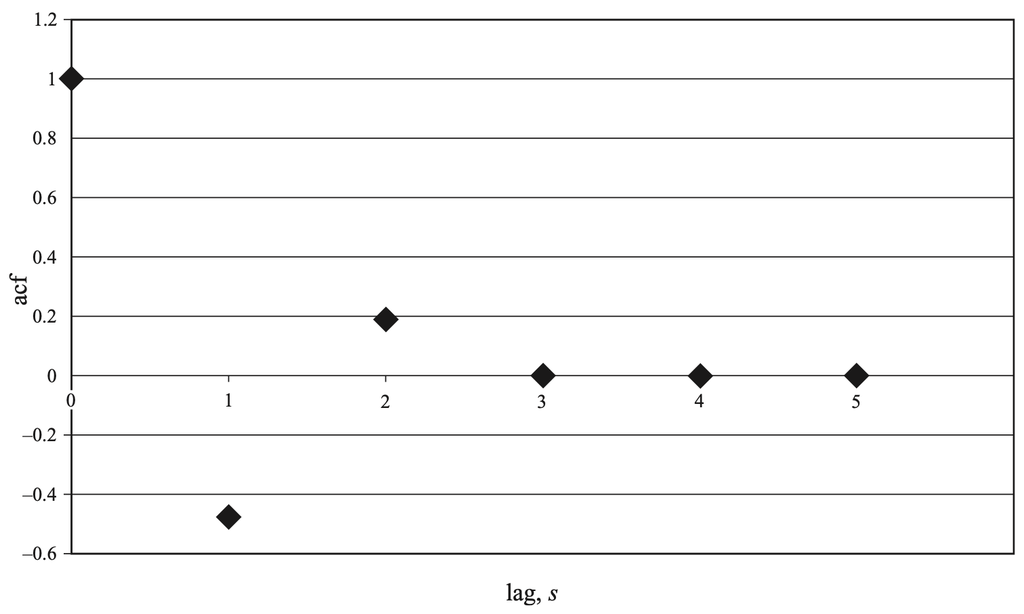

FAC de $y_t = u_t + \theta_1 u_{t-1} + \theta_2 u_{t-2}$

# Processo Autorregressivo de Médias Móveis

## Processos ARMA

**Definição**

- Ao combinar os modelos AR($p$) e MA($q$), podemos obter um modelo ARMA($p,q$) que pode ser descrito por:

$$\begin{aligned}
y_t &= \mu + \phi _1 y_{t - 1} + \phi _2 y_{t - 2} +\cdots+\phi _p y_{t - p}+\theta _1 u_{t - 1}\\[6pt]
&+\,\theta _2 u_{t - 2}+\cdots + \theta _q u_{t - q} + u_t
\end{aligned}$$

Sendo

$$E(u_t )=0; E\big(u_t^2 \big)=\sigma^2; E(u_t u_s)=0, t \ne s \nonumber$$

Utilizando o operador $L$, podemos escrever o processo como:

$$\phi (L)y_t = \mu + \theta (L)u_t$$

em que

$$\begin{aligned}
\phi(L) &= 1 - \phi_1 L - {\phi_2} L^2 -\,\cdots - \phi _p L^p{\quad}{\rm e} \\
\theta(L) &= 1+\theta_1 L + {\theta_2} L^2 +\cdots +\theta _q L^q
\end{aligned}$$

## A Condição de Invertibilidade

**Definição**

- De forma semelhante à condição de estacionariedade, normalmente exigimos que a parte MA($q$) do modelo tenha raízes de $\theta(z)=0$ maiores do que um, em valor absoluto.
- A média de um processo ARMA é dada por

$$\begin{aligned}
E(y_t ) = \frac{\mu }{1 - \phi _1 - \phi _2 -\cdots- \phi _p }
\end{aligned}$$

- A função de autocorrelação de um processo ARMA exibirá combinações de comportamentos derivados das partes AR e MA, mas para defasagens acima de $q$, a FAC será idêntica à do modelo AR($p$) isolado.

## Simulação de um Processo ARMA(p,q)

```r
# Parâmetros
set.seed(123)
n <- 100            # número de observações
phi1 <- 0.7         # parâmetro autorregressivo de 1ª ordem
theta1 <- 0.5       # Parâmetro média móvel de 1ª ordem
sigma <- 1          # desvio-padrão do ruido branco

# Simula o processo ARMA(1,1)
y_arma11 <- arima.sim(n = n, model = list(ar = phi1, ma = theta1), sd = sigma)

# Visualização
plot(
  y_arma11 ,
  type = "l",
  main = expression(
    "Processo ARMA(1,1) Simulado, "*phi[1]*" = 0.7, "*theta[1]* " = 0.5"
  ),
  ylab = "Valor",
  xlab = "Tempo"
)

# adiciona reta horizontal em y = 0
abline(h = 0, col = "blue", lty = 2)
```

## Simulação de um Processo ARMA(p,q)

[figure not shown]

# FAC e FACP de Processos AR e MA

## Resumo

**Comportamento da FAC e FACP para Processos AR e MA**

Um processo autorregressivo $AR(p)$ possui

- FAC apresenta decaimento geométrico
- número de picos da FACP = ordem $p$ do processo AR

Um processo de médias móveis $MA(q)$ possui

- número de picos da FAC = ordem $q$ do processo MA
- FACP apresenta decaimento geométrico

## FAC e FACP Amostrais de Processos Básicos

**Dados utilizados (Brooks, 2019)**

- A FAC e a FACP exibidas a seguir não foram produzidas analiticamente a partir das fórmulas do modelo correspondente; em vez disso, foram estimadas com 100.000 observações simuladas, com os erros/choques simulados de uma distribuição normal.

## Modelo MA(1)

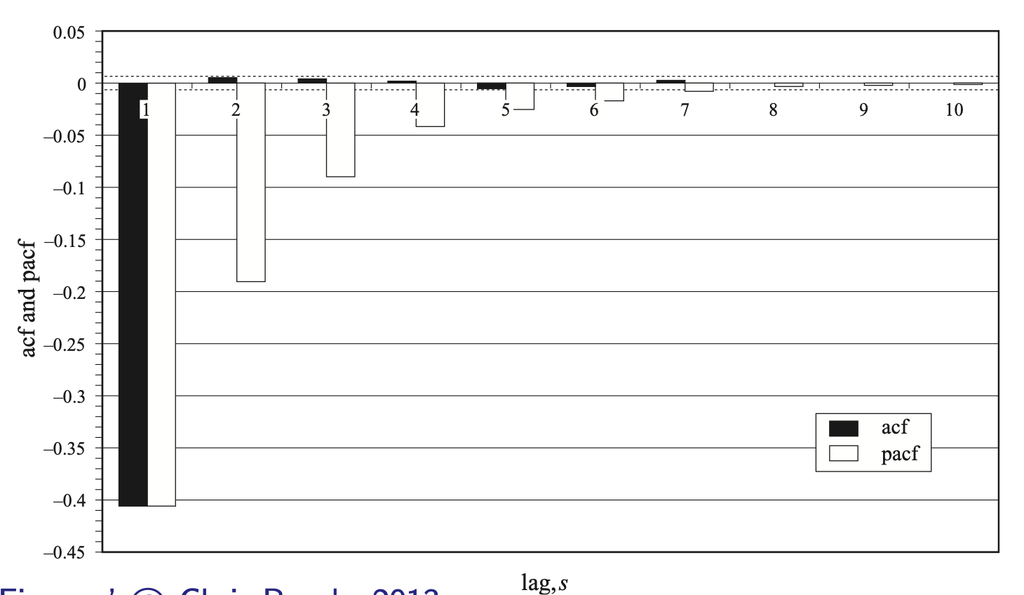

FAC e FACP amostrais para um modelo MA(1): $y_{t} = -0.5u_{t-1} + u_t$

## Modelo MA(2)

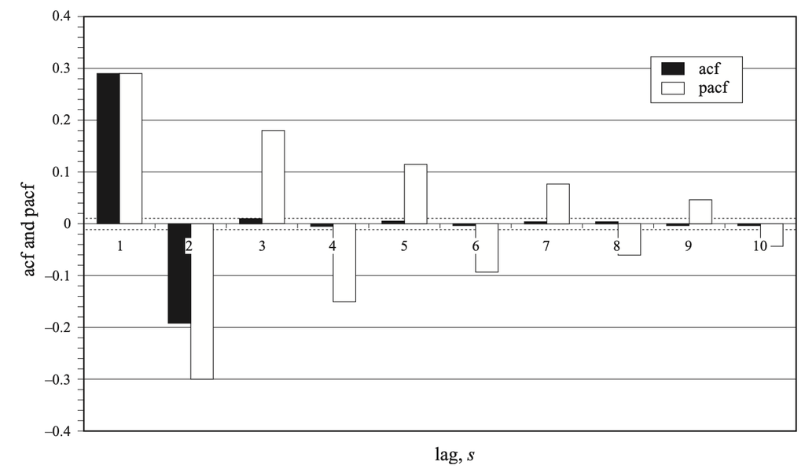

FAC e FACP amostrais para um modelo MA(2): $y_t = 0.5 u_{t-1} - 0.25 u_{t-2} + u_t$

## Modelo AR(1)

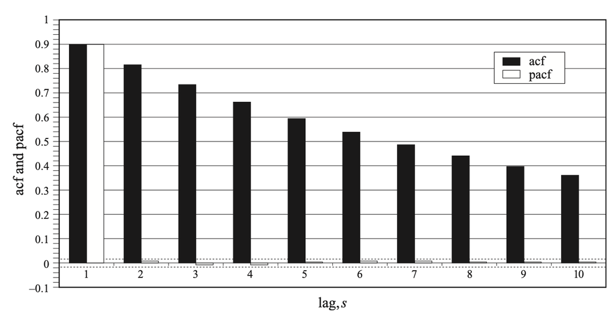

FAC e FACP amostrais para um modelo AR(1) com decaimento lento: $y_t = 0.9y_{t-1} + u_t$

## Modelo AR(1)

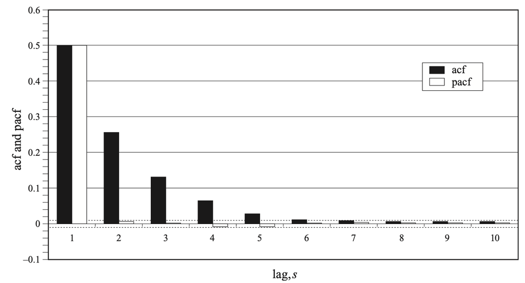

FAC e FACP amostrais para um modelo AR(1) com decaimento mais rápido: $y_t = 0.5 y_{t-1} + u_t$

## Modelo AR(1)

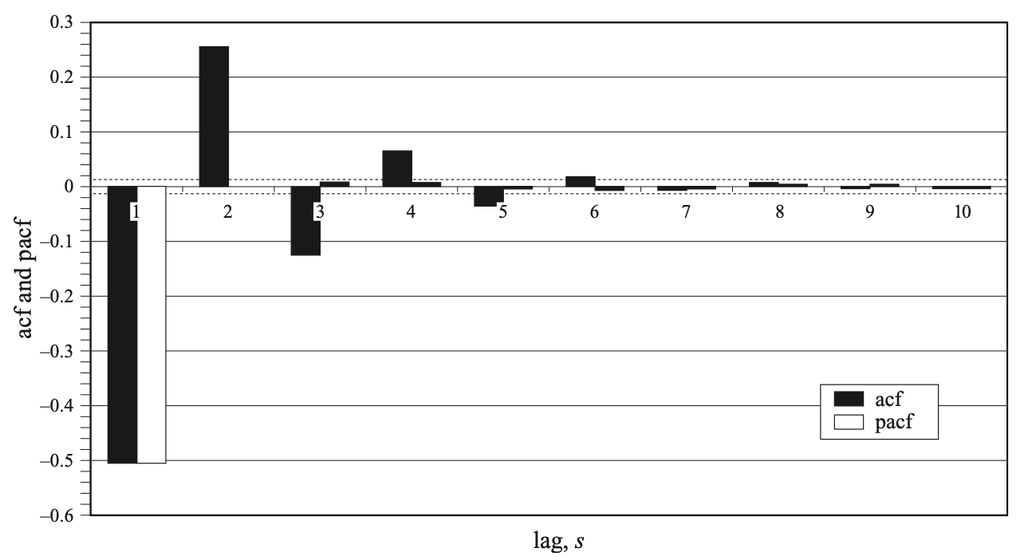

FAC e FACP amostrais para um modelo AR(1) com decaimento mais rápido e coeficiente negativo: $y_t = - 0.5 y_{t-1} +u_t$

## Modelo AR(1)

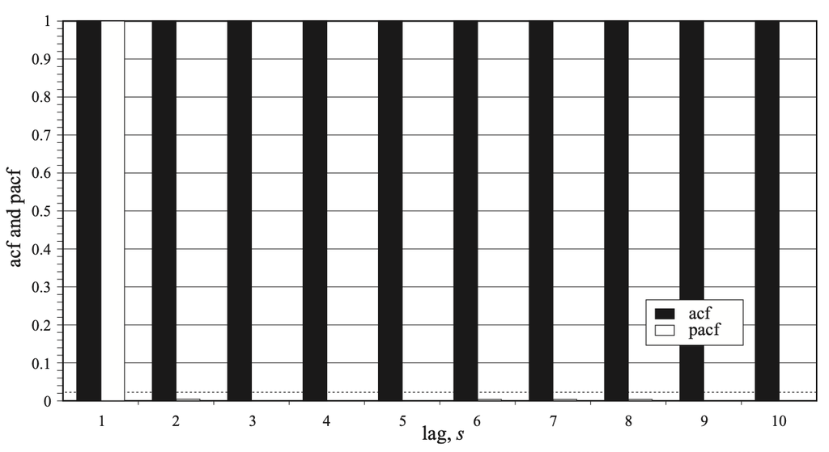

FAC e FACP amostrais para um modelo não estacionário: $y_t = y_{t-1} + u_t$

## Modelo ARMA(1,1)

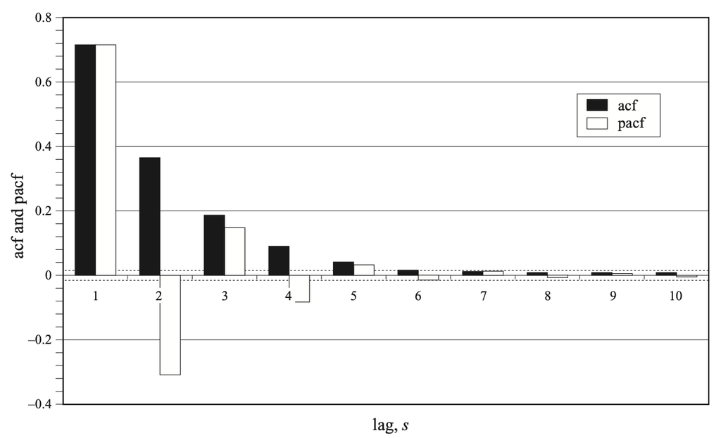

FAC e FACP amostrais para um ARMA(1,1): $y_t= 0.5 y_{t-1} + 0.5 u_{t-1} + u_t$

# Metodologia de Box & Jenkins

## Metodologia de Box e Jenkins (1970)

**Etapas**

- Box e Jenkins (1970) propuseram uma abordagem sistemática para **identificar, estimar e diagnosticar** modelos ARMA.
- Essa metodologia é geralmente apresentada em **três etapas**:
1. **Identificação**
2. **Estimação**
3. **Diagnóstico**

## Metodologia de Box e Jenkins (1970)

**Etapa 1: Identificação**

- Nesta etapa, buscamos definir ordens plausíveis para o modelo, isto é, os valores de $p$ e $q$.
- Na abordagem clássica, a **FAC** e a **FACP** são utilizadas como ferramentas de apoio à identificação.
- Na prática, essa escolha também pode ser auxiliada por **critérios de informação** e pelo **diagnóstico dos resíduos**.

## Metodologia de Box e Jenkins (1970)

**Etapa 2: Estimação**

- Nesta etapa, estimamos os parâmetros do(s) modelo(s) candidato(s).
- Em termos gerais, diferentes métodos de estimação podem ser usados.
- Em modelos ARMA, é comum utilizar o método da **máxima verossimilhança**.

## Metodologia de Box e Jenkins (1970)

**Etapa 3: Diagnóstico**

Box e Jenkins (1970) destacam dois procedimentos importantes:

- **superajuste deliberado**: ajustar um modelo com mais parâmetros do que o inicialmente necessário para verificar se termos adicionais parecem relevantes;
- **diagnóstico dos resíduos**: verificar se os resíduos do modelo se comportam aproximadamente como **ruído branco**.
- O objetivo desta etapa é avaliar se o modelo ajustado parece adequado para descrever a dinâmica da série.

## Modelagem ARMA

**Desenvolvimentos posteriores**

- Na prática atual, a identificação de modelos ARMA raramente é feita apenas com base na FAC e na FACP.
- Em geral, buscamos um modelo **parcimonioso**, isto é, um modelo que explique bem os dados com poucos parâmetros.
- Isso é importante porque:
- modelos com muitos parâmetros consomem graus de liberdade;
- as estimativas podem se tornar menos precisas;
- modelos excessivamente complexos podem se ajustar a particularidades da amostra.
- Esse problema motiva o uso de **critérios de informação**.

## Critérios de Informação para Seleção de Modelos

**Descrição**

- Critérios de informação procuram equilibrar dois objetivos:
  - **bom ajuste** aos dados;
  - **parcimônia**.
- Os três critérios mais conhecidos são:
  - critério de informação de **Akaike** (*AIC*);
  - critério de informação **bayesiano** (*BIC*);
  - critério de **Hannan-Quinn** (*HQIC*).

$$\begin{aligned}
AIC &= \ln(\hat{\sigma}^2)+\frac{2k}{T} \\
BIC &= \ln(\hat{\sigma}^2)+\frac{k\ln T}{T} \\
HQIC &= \ln(\hat{\sigma}^2)+\frac{2k\ln(\ln T)}{T}
\end{aligned}$$

em que $k = p+q+1$ e $T$ é o tamanho da amostra.

## Critérios de Informação para Seleção de Modelos

**Interpretação**

- A ideia é escolher, entre os modelos candidatos, aquele que **minimiza** o critério de informação, sujeito a limites como $p \leq \bar{p}$ e $q \leq \bar{q}$.
- O **BIC** penaliza mais fortemente a inclusão de parâmetros adicionais do que o **AIC**.
- Por isso, quando os critérios sugerem modelos diferentes:
  - o **AIC** tende a selecionar modelos maiores;
  - o **BIC** tende a selecionar modelos menores.
- Em termos assintóticos, o **BIC** é consistente sob condições usuais, enquanto o **AIC** não é consistente para identificar a ordem verdadeira.

# Como fazer previsões

## Previsão em Econometria

**O que é uma previsão?**

- Previsão (*forecasting*) é, essencialmente, o ato de predizer valores futuros.
- A capacidade preditiva de um modelo é um critério importante para avaliar sua adequação.
- Exemplos:
  - prever o retorno de amanhã de uma determinada ação;
  - prever o preço de uma casa com base em suas características;
  - prever o risco de uma carteira no próximo ano;
  - prever a volatilidade dos retornos de títulos.

## Previsão em Econometria

**Modelos estruturais vs. séries temporais**

Podemos distinguir, de forma ampla, duas abordagens:

- **previsão econométrica (estrutural)**;
- **previsão por séries temporais**.

#### Observação

Na prática, a distinção entre essas duas abordagens nem sempre é nítida.

Por exemplo, alguns modelos, como os VARs, ficam em uma zona intermediária.

## Dentro da Amostra versus Fora da Amostra

**Descrição**

- Espera-se que o ajuste do modelo seja bom **dentro da amostra** (*in-sample*).
- Suponha que tenhamos, por exemplo, retornos mensais do índice FTSE para 120 meses: de 1990M1 até 1999M12.
- Podemos usar toda a amostra para estimar o modelo ou reservar parte das observações para avaliação preditiva.

## Dentro da Amostra versus Fora da Amostra

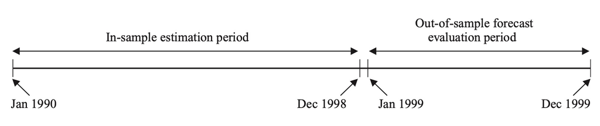

Esse procedimento fornece um bom teste do modelo, pois as observações reservadas não foram usadas na estimação dos parâmetros.

## Como Produzir Previsões

**Descrição**

- Previsões de **um passo à frente** versus **múltiplos passos à frente**;
- janelas **recursivas** versus **móveis** (*rolling windows*);
- Para entender como construir previsões, precisamos da ideia de **esperança condicional**:

$$E(y_{t+1}\mid \Omega_t),$$

em que $\Omega_t$ representa o conjunto de informações disponível no instante $t$.

## Como Produzir Previsões

**Exemplo: ruído branco**

Não podemos prever um processo ruído branco a partir de sua história passada, pois

$$E(u_{t+s}\mid \Omega_t)=0, \qquad \forall s>0.$$

Ou seja, a melhor previsão é simplesmente sua média c ondicional, que é zero.

## Modelos ingênuos

**Descrição**

As duas regras (modelos) mais simples de previsão são:

1. **supor ausência de mudança**:
   $$f(y_{t+s}) = y_t;$$
2. **usar a média de longo prazo**:
   $$f(y_{t+s}) = \bar{y}.$$

## Modelos para Previsão

**Modelos estruturais**

Um modelo estrutural típico pode ser escrito como

$$y_t = \beta_1 + \beta_2 x_{2t} + \beta_3 x_{3t} + \cdots + \beta_k x_{kt} + u_t.$$

Para prever $y_t$, precisamos da esperança condicional de seu valor futuro.

## Modelos para Previsão

**Modelos estruturais**

Se $E(u_t\mid \Omega_{t-1})=0$, então

$$E(y_t \mid \Omega_{t-1})
= \beta_1 + \beta_2 E(x_{2t}\mid \Omega_{t-1})
+ \beta_3 E(x_{3t}\mid \Omega_{t-1})
+ \cdots
+ \beta_k E(x_{kt}\mid \Omega_{t-1}).$$

Portanto, para prever $y_t$, também precisamos prever os regressores futuros.

## Modelos para Previsão

**Modelos estruturais**

Mas como obter $E(x_{2t}\mid \Omega_{t-1})$, $E(x_{3t}\mid \Omega_{t-1})$ etc.?

Uma possibilidade simplificadora é substituir esses termos pelas médias amostrais dos regressores:

$$E(x_{jt}\mid \Omega_{t-1}) \approx \bar{x}_j.$$

Nesse caso,

$$E(y_t)
\approx
\beta_1 + \beta_2 \bar{x}_2 + \beta_3 \bar{x}_3 + \cdots + \beta_k \bar{x}_k.$$

## Modelos para Previsão

**Modelos estruturais**

Se o modelo inclui intercepto e foi estimado por MQO com constante, então

$$\bar{y} = \hat{\beta}_1 + \hat{\beta}_2 \bar{x}_2 + \hat{\beta}_3 \bar{x}_3 + \cdots + \hat{\beta}_k \bar{x}_k.$$

Assim, ao substituir regressores futuros por suas médias amostrais, a previsão resultante tende a coincidir com a média amostral de $y$.

## Modelos para Previsão

**Modelos de séries temporais**

Nos modelos de séries temporais, o valor corrente de uma variável, $y_t$, é modelado como função:

- de seus próprios valores passados;
- do valor corrente do erro;
- e, possivelmente, de valores passados do erro.

## Modelos para Previsão

**Modelos de séries temporaiss**

Exemplos de modelos usados para previsão:

- médias simples não ponderadas;
- médias ponderadas exponencialmente;
- modelos ARIMA;
- modelos não lineares, como:
  - modelos limiares (*threshold models*);
  - modelos GARCH;
  - modelos bilineares.

## Previsão com Modelos ARMA

**Descrição**

Um modelo geral de previsão com estrutura ARMA pode ser escrito como

$$f_{t,s} = \sum_{i=1}^{p} a_i f_{t,s-i} + \sum_{j=1}^{q} b_j u_{t+s-j},$$

em que $f_{t,s}$ representa a previsão feita no instante $t$ para $y_{t+s}$. Sendo:

$$\begin{aligned}
f_{t,s} &= y_{t+s}, \qquad s \leq 0, \\
u_{t+s} &= 0, \qquad s > 0, \\
&= u_{t+s}, \qquad s \leq 0,
\end{aligned}$$

Para interpretar a expressão anterior, adotamos as convenções:

$$f_{t,s} = y_{t+s}, \qquad s \leq 0,$$

isto é, para datas já observadas, a “previsão” coincide com o valor realizado;

e

$$u_{t+s} = 0, \qquad s > 0,$$

pois choques futuros têm esperança condicional igual a zero dado o conjunto de informações disponível em $t$.

Além disso, para datas presentes ou passadas,

$$u_{t+s} = u_{t+s}, \qquad s \leq 0,$$

pois esses choques já pertencem ao conjunto de informações disponível no instante $t$.

## Previsão com Modelos ARMA

**Ideia central**

Na prática, previsões com modelos ARMA são obtidas substituindo:

- valores passados observados, quando disponíveis;
- choques futuros por zero;
- previsões anteriores, quando surgem valores futuros de $y$ no lado direito da equação.

## Previsão com Modelos MA

**Descrição**

- Um processo MA($q$) “tem memória” de apenas $q$ períodos.
- Por exemplo, suponha que tenhamos estimado um modelo MA(3):

$$y_t = \mu + \theta_1 u_{t-1} + \theta_2 u_{t-2} + \theta_3 u_{t-3} + u_t,$$

Estamos no instante $t$ e queremos prever $1,2,\ldots,s$ passos à frente.

$$\begin{aligned}
y_{t+1} &= \mu + \theta_1 u_t + \theta_2 u_{t-1} + \theta_3 u_{t-2} + u_{t+1}, \\
y_{t+2} &= \mu + \theta_1 u_{t+1} + \theta_2 u_t + \theta_3 u_{t-1} + u_{t+2}, \\
y_{t+3} &= \mu + \theta_1 u_{t+2} + \theta_2 u_{t+1} + \theta_3 u_t + u_{t+3}
\end{aligned}$$

## Previsão com Modelos MA

**Descrição**

Sabemos os valores passados de $y$ e os choques já realizados, como $u_t$, $u_{t-1}$ etc.

Assim, a previsão de 1 passo à frente é:

$$f_{t,1} = E(y_{t+1}\mid \Omega_t) = \mu + \theta_1 u_t + \theta_2 u_{t-1} + \theta_3 u_{t-2}.$$

Para 2 passos à frente:

$$\begin{aligned}
f_{t,2} &= E(y_{t+2}\mid \Omega_t) \\
&= E\bigl(\mu + \theta_1 u_{t+1} + \theta_2 u_t + \theta_3 u_{t-1} + u_{t+2}\mid \Omega_t\bigr) \\
&= \mu + \theta_2 u_t + \theta_3 u_{t-1}.
\end{aligned}$$

Como $u_{t+1}$ e $u_{t+2}$ são choques futuros, suas esperanças condicionais são zero.

Para 3 passos à frente:

$$\begin{aligned}
f_{t,3} &= E(y_{t+3}\mid \Omega_t) \\
&= E\bigl(\mu + \theta_1 u_{t+2} + \theta_2 u_{t+1} + \theta_3 u_t + u_{t+3}\mid \Omega_t\bigr) \\
&= \mu + \theta_3 u_t.
\end{aligned}$$

Para 4 passos à frente:

$$f_{t,4} = E(y_{t+4}\mid \Omega_t) = \mu.$$

Logo,

$$f_{t,s} = \mu, \qquad \forall s \geq 4.$$

## Previsão com Modelos MA

**Interpretação**

Em um modelo MA($q$), os efeitos dos choques passados desaparecem após $q$ períodos.

Por isso, previsões suficientemente distantes convergem para a média incondicional do processo.

## Previsão com Modelos AR

**Descrição**

- Suponha agora que tenhamos estimado um modelo AR(2):

$$y_t = \mu + \phi_1 y_{t-1} + \phi_2 y_{t-2} + u_t.$$

## Previsão com Modelos AR

**Descrição**

Defasando a equação, obtemos:

$$y_{t+1} = \mu + \phi_1 y_t + \phi_2 y_{t-1} + u_{t+1},$$

$$y_{t+2} = \mu + \phi_1 y_{t+1} + \phi_2 y_t + u_{t+2},$$

$$y_{t+3} = \mu + \phi_1 y_{t+2} + \phi_2 y_{t+1} + u_{t+3}.$$

## Previsão com Modelos AR

**Descrição**

A previsão de 1 passo à frente é:

$$\begin{aligned}
f_{t,1}
&=
E(y_{t+1}\mid \Omega_t) \\
&=
E(\mu + \phi_1 y_t + \phi_2 y_{t-1} + u_{t+1}\mid \Omega_t) \\
&=
\mu + \phi_1 y_t + \phi_2 y_{t-1}.
\end{aligned}$$

## Previsão com Modelos AR

**Descrição**

A previsão de 2 passos à frente é:

$$\begin{aligned}
f_{t,2}
&=
E(y_{t+2}\mid \Omega_t) \\
&=
E(\mu + \phi_1 y_{t+1} + \phi_2 y_t + u_{t+2}\mid \Omega_t) \\
&=
\mu + \phi_1 E(y_{t+1}\mid \Omega_t) + \phi_2 y_t \\
&=
\mu + \phi_1 f_{t,1} + \phi_2 y_t.
\end{aligned}$$

## Previsão com Modelos AR

**Descrição**

A previsão de 3 passos à frente é:

$$\begin{aligned}
f_{t,3}
&=
E(y_{t+3}\mid \Omega_t) \\
&=
E(\mu + \phi_1 y_{t+2} + \phi_2 y_{t+1} + u_{t+3}\mid \Omega_t) \\
&=
\mu + \phi_1 E(y_{t+2}\mid \Omega_t) + \phi_2 E(y_{t+1}\mid \Omega_t) \\
&=
\mu + \phi_1 f_{t,2} + \phi_2 f_{t,1}.
\end{aligned}$$

## Previsão com Modelos AR

**Descrição**

Podemos ver imediatamente que, em geral,

$$f_{t,4} = \mu + \phi_1 f_{t,3} + \phi_2 f_{t,2},$$

e, mais geralmente,

$$f_{t,s} = \mu + \phi_1 f_{t,s-1} + \phi_2 f_{t,s-2}.$$

#### Em resumo

Em modelos AR, previsões de vários passos à frente são obtidas recursivamente, substituindo valores futuros desconhecidos por previsões anteriores.

## Previsão com Modelos ARMA

**Descrição**

- Previsões com modelos ARMA($p,q$) podem ser obtidas da mesma forma.
- Em cada horizonte de previsão:
  - usamos valores observados quando eles já são conhecidos;
  - substituímos choques futuros por zero;
  - substituímos valores futuros de $y$ por previsões já calculadas.

## Como avaliar se uma previsão foi acurada?

**Descrição**

- Suponha que previmos o retorno de amanhã do índice FTSE como $0{,}20$, mas o valor realizado foi $-0{,}40$.
- Essa previsão foi boa?
- Seja $f_{t,s}$ a previsão feita no instante $t$ para $s$ passos à frente, isto é, a previsão de $y_{t+s}$.
- Seja $y_{t+s}$ o valor efetivamente realizado no instante $t+s$.

## Como avaliar se uma previsão foi acurada?

*Mean squere error** (MSE) e *Mean absolute error* (MAE)

As medidas estatísticas mais usadas para avaliar previsões são:

#### Erro Quadrático Médio (MSE)

$$\text{MSE}
=
\frac{1}{N}\sum_{t=1}^{N}(y_{t+s}-f_{t,s})^2$$

#### Erro Absoluto Médio (MAE)

$$\text{MAE}
=
\frac{1}{N}\sum_{t=1}^{N}\left|y_{t+s}-f_{t,s}\right|$$

## Como avaliar se uma previsão foi acurada?

**Erro Percentual Absoluto Médio (MAPE)**

$$\text{MAPE}
=
\frac{100}{N}\sum_{t=1}^{N}
\left|
\frac{y_{t+s}-f_{t,s}}{y_{t+s}}
\right|$$

**Observação:**

- O MAPE pode ser problemático quando os valores realizados $y_{t+s}$ são muito próximos de zero ou iguais a zero.

## Como avaliar se uma previsão foi acurada?

**Sinal da previsão**

Em finanças, muitas vezes não importa apenas o tamanho do erro, mas também se a previsão acertou a **direção** do movimento.

Uma medida útil é a **porcentagem de previsões com sinal correto**:

$$\%\text{ de previsões com sinal correto}
=
\frac{1}{N}\sum_{t=1}^{N} z_{t+s}$$

em que

$$z_{t+s}=
\begin{cases}
1, & \text{se } y_{t+s}f_{t,s}>0,\\
0, & \text{caso contrário.}
\end{cases}$$

## Como avaliar se uma previsão foi acurada?

**Observação importante**

- Já foi mostrado na literatura que medidas estatísticas tradicionais de acurácia, como MSE e MAE, podem não estar fortemente relacionadas à lucratividade de uma estratégia de negociação.
- Por isso, em aplicações financeiras, pode ser útil complementar a avaliação estatística com medidas mais próximas do objetivo econômico.

## Exemplo

**Avaliação de Previsões**

Com base nas previsões e valores realizados abaixo, calculeo MSE, o MAE e a porcentagem de previsões com sinal correto.

| Passos à frente | Previsão | Realizado |
| --- | --- | --- |
| 1 | 0.20 | -0.40 |
| 2 | 0.15 | 0.20 |
| 3 | 0.10 | 0.10 |
| 4 | 0.06 | -0.10 |
| 5 | 0.04 | -0.05 |

## Exemplo

**Avaliação de Previsões**

Os resultados são:

- $\text{MSE} = 0{,}079$
- $\text{MAE} = 0{,}180$
- $\%\text{ de sinais corretos} = 40\%$

**Interpretação**

Essas medidas resumem dimensões diferentes da qualidade da previsão:

- MSE penaliza mais fortemente erros grandes;
- MAE mede o erro médio em valor absoluto;
- a taxa de sinais corretos mede se o modelo acerta a direção do movimento.

## Exemplo

**Cálculo detalhado do MSE**

Lembre que

$$\text{MSE}=\frac{1}{N}\sum_{t=1}^{N} e_t^2.$$

Neste exemplo:

$$\begin{aligned}
\text{MSE} &= \frac{(-0.60)^2 + (0.05)^2 + (0.00)^2 + (-0.16)^2 + (-0.09)^2}{5} \\
&= \frac{0.3600 + 0.0025 + 0.0000 + 0.0256 + 0.0081}{5} \\
&= \frac{0.3962}{5} \\
&= 0.07924 \approx 0.079
\end{aligned}$$

## Exemplo

**Cálculo detalhado do MAE**

Lembre que

$$\text{MAE}=\frac{1}{N}\sum_{t=1}^{N} |e_t|.$$

Neste exemplo:

$$\begin{aligned}
\text{MAE} &= \frac{|{-0.60}| + |0.05| + |0.00| + |{-0.16}| + |{-0.09}|}{5} \\
&= \frac{0.60 + 0.05 + 0.00 + 0.16 + 0.09}{5} \\
&= \frac{0.90}{5} \\
&= 0.18
\end{aligned}$$

## O que favorece um bom modelo de previsão?

**Descrição**

Alguns fatores importantes são:

- relação entre **sinal** e **ruído** nos dados;
- problemas de **data mining** e sobreajuste;
- escolha entre modelos **simples** e **complexos**;
- uso de teoria econômica ou financeira na especificação do modelo.

## Funções de perda estatísticas versus econômicas

**Pergunta central**

- Métricas estatísticas de avaliação nem sempre são suficientes.
- Também devemos perguntar:
- A previsão desempenha bem a tarefa para a qual foi construída?
- Em finanças e economia, muitas vezes o objetivo não é apenas minimizar erro, mas apoiar decisão.

## Limites da previsão

**Descrição**

- Modelos estatísticos de previsão são, em essência, extrapolativos.
- Eles tendem a funcionar pior em pontos de reversão da série.
- Séries sujeitas a mudanças estruturais ou mudanças de regime são particularmente difíceis de prever.
- Em geral, a acurácia preditiva diminui quando o horizonte de previsão aumenta.
- Previsão não substitui julgamento.

## Voltando à pergunta original

**por que prever?**

- Por que não usar apenas “especialistas” para fazer previsões?
- Previsões puramente subjetivas também têm problemas.

Pesquisas em psicologia mostram que julgamentos de especialistas podem estar sujeitos a vieses como:

- excesso de confiança;
- inconsistência;
- viés de recência;
- ancoragem;
- percepção ilusória de padrões;
- pensamento de grupo (*groupthink*).

## Qual é a abordagem geralmente mais adequada?

**Abordagem recomendada**

- Usar um modelo estatístico de previsão construído sobre fundamentos teóricos sólidos, complementado por julgamento especializado e interpretação substantiva.
- Ou seja, nem previsão puramente mecânica, nem julgamento puramente subjetivo.
- Em geral, a melhor abordagem combina **modelo + teoria + interpretação**.

# Modelos ARMA: aplicação da metodologia de Box & Jenkins

## Exemplo empírico

**Objetivo**

Nesta parte final da aula, vamos ilustrar como os conceitos de:

- Estacionariedade;
- Modelos AR, MA e ARMA;
- FAC e FACP;

podem ser usados, na prática, na modelagem de uma série temporal.

## Exemplo empírico

**Objetivo**

O objetivo é executar as etapas da metodologia de Box e Jenkins (1970):

1. Análise exploratória dos dados;
2. Identificação de modelos candidatos;
3. Estimação e seleção;
4. Diagnóstico dos resíduos;
5. Previsão.

## Dados

**Descrição**

- Este exemplo, adaptado de Brooks (2019), utiliza uma série mensal de preços de casas no Reino Unido.
- Os dados estão armazenados no arquivo `UKHP.xls`.
- Para fins de modelagem, trabalharemos com a **variação percentual mensal** da série de preços de casas, e **não com o nível** da série.
- Como a variação percentual mensal depende da observação do mês anterior, a primeira observação dessa nova série fica ausente.

## Importação dos Dados

```r
# carrega pacotes que serão usados na importação e manipulação dos dados
library(tidyverse)
library(here)
library(readxl)
library(forecast)

# define o caminho do arquivo de dados
path_xls <- here("dados/brutos/UKHP.xls")

# importa a planilha com os dados de preços de casas
ukhp <- read_xls(path_xls)

# exibe a estrutura geral do objeto importado
dplyr::glimpse(ukhp)
```

```
#> Rows: 327
#> Columns: 2
#> $ Month                 <dttm> 1991-01-01, 1991-02-01, 1991-03-01, 1991-04-01,…
#> $ `Average House Price` <dbl> 53051.72, 53496.80, 52892.86, 53677.44, 54385.73…
```

## Preparação dos Dados

```r
# pipeline de preparação dos dados

# salva o resultado no objeto ukhp_limpos
ukhp_limpos <- ukhp |>
  # altera o nome e o tipo da variável Month
  # altera o nome da série de preços
  # cria os retornos percentuais mensais
  mutate(
    mes = as.Date(Month),
    hp = `Average House Price`,
    hp_ret = 100 * ((hp - lag(hp)) / lag(hp))
  ) |>
  # remove o dado faltante de hp_ret
  drop_na()

# exibe o objeto criado
dplyr::glimpse(ukhp_limpos)
```

```
#> Rows: 326
#> Columns: 5
#> $ Month                 <dttm> 1991-02-01, 1991-03-01, 1991-04-01, 1991-05-01,…
#> $ `Average House Price` <dbl> 53496.80, 52892.86, 53677.44, 54385.73, 55107.38…
#> $ mes                   <date> 1991-02-01, 1991-03-01, 1991-04-01, 1991-05-01,…
#> $ hp                    <dbl> 53496.80, 52892.86, 53677.44, 54385.73, 55107.38…
#> $ hp_ret                <dbl> 0.8389504256, -1.1289220193, 1.4833261822, 1.319…
```

## Preparação dos Dados

**Por que modelar a variação percentual?**

- Em muitas aplicações, a série em nível pode apresentar tendência marcada e forte persistência.
- Ao trabalhar com a variação percentual mensal, buscamos obter uma série com comportamento mais próximo da estacionariedade, o que favorece o uso de modelos ARMA.
- Nesta aula, a ideia é justamente ilustrar um caso em que modelamos uma série já transformada, sem introduzir ainda a lógica completa dos modelos ARIMA.

## Etapa 1: Análise Exploratória

**Visualização da série**

O gráfico de linha permite avaliar, de forma preliminar:

- se a série oscila em torno de um nível relativamente estável;
- se há tendência visível na média;
- e se existem períodos de maior ou menor variabilidade.

Essa inspeção inicial ajuda a julgar se a hipótese de estacionariedade parece plausível para a série transformada.

## Etapa 1: Análise Exploratória

```r
# gráfico de linha da variação percentual mensal
ukhp_limpos |>
  ggplot(aes(x = mes, y = hp_ret)) +
  geom_line() +
  labs(
    title = "Variação percentual mensal dos preços de casas no Reino Unido",
    x = "Mês",
    y = "Variação (%)"
  ) +
  theme_minimal()
```

## Etapa 1: Análise Exploratória

[figure not shown]

## Etapa 1: Análise Exploratória

**Distribuição da série**

Um histograma e estatísticas descritivas ajudam a examinar aspectos como:

- simetria/assimetria;
- variabilidade da série;
- curtose;
- outliers (valores exetremos).

Essas informações são úteis para caracterizar a série antes da etapa de identificação do modelo.

## Etapa 1: Análise Exploratória

```r
# histograma da variação percentual mensal
ukhp_limpos |>
  ggplot(aes(x = hp_ret)) +
  geom_histogram(bins = 30, fill = "steelblue", color = "black") +
  labs(
    title = "Histograma da variação percentual mensal",
    x = "Variação (%)",
    y = "Frequência"
  ) +
  theme_minimal()
```

## Etapa 1: Análise Exploratória

[figure not shown]

## Etapa 1: Análise Exploratória

```r
# estatísticas descritivas dos retornos
fBasics::basicStats(ukhp_limpos$hp_ret)
```

```
#>             X..ukhp_limpos.hp_ret
#> nobs                   326.000000
#> NAs                      0.000000
#> Minimum                 -3.404716
#> Maximum                  3.802188
#> 1. Quartile             -0.255697
#> 3. Quartile              1.152205
#> Mean                     0.431520
#> Median                   0.448334
#> Sum                    140.675474
#> SE Mean                  0.061958
#> LCL Mean                 0.309631
#> UCL Mean                 0.553408
#> Variance                 1.251429
#> Stdev                    1.118673
#> Skewness                -0.081653
#> Kurtosis                 0.585711
```

## Etapa 2: Identificação — FAC

```r
# exibe a função de autocorrelação da série
acf(ukhp_limpos$hp_ret)
```

[figure not shown]

## Etapa 2: Identificação — FACP

```r
# exibe a função de autocorrelação parcial da série
pacf(ukhp_limpos$hp_ret)
```

[figure not shown]

## Etapa 2: Identificação

**leitura da FAC e da FACP**

- A FAC e a FACP ajudam a identificar padrões de dependência serial e a propor modelos ARMA candidatos.
- Nesta etapa, o foco não é determinar automaticamente um único modelo final, mas construir um conjunto pequeno de especificações plausíveis para a etapa de estimação.
- A escolha final dependerá também de critérios de informação e do diagnóstico dos resíduos.

## Etapa 2: identificação

**Modelos candidatos**

Com base na FAC e FACP, os seguintes modelos são plausíveis:

- ARMA(2,0,4);
- ARMA(2,0,3);
- ARMA(2,0,2);
- ARMA(2,0,1).

## Etapa 3: estimação e seleção de modelos

```r
# ajusta o modelo candidato definido a partir da FAC e da FACP
mod_1 <- forecast::Arima(ukhp_limpos$hp_ret, order = c(2, 0, 4))
mod_2 <- forecast::Arima(ukhp_limpos$hp_ret, order = c(2, 0, 3))
mod_3 <- forecast::Arima(ukhp_limpos$hp_ret, order = c(2, 0, 2))
mod_4 <- forecast::Arima(ukhp_limpos$hp_ret, order = c(2, 0, 1))

# ajusta também um modelo por seleção automática
# para comparação
mod_auto <- forecast::auto.arima(ukhp_limpos$hp_ret,
                                 d = 0,
                                 max.d = 0,
                                 ic = "bic")
mod_auto
```

```
#> Series: ukhp_limpos$hp_ret
#> ARIMA(2,0,0) with non-zero mean
#>
#> Coefficients:
#>          ar1     ar2    mean
#>       0.2361  0.3340  0.4275
#> s.e.  0.0521  0.0523  0.1259
#>
#> sigma^2 = 0.9756:  log likelihood = -457.23
#> AIC=922.46   AICc=922.58   BIC=937.61
```

```r
# compara os modelos via BIC
BIC(mod_1, mod_2, mod_3, mod_4, mod_auto)
```

```
#>          df      BIC
#> mod_1     8 956.3990
#> mod_2     7 952.9171
#> mod_3     6 948.9641
#> mod_4     5 943.3425
#> mod_auto  4 937.6076
```

## Etapa 3: estimação e seleção de modelos

**O que observar nesta etapa?**

Após estimar os modelos candidatos, segundo o BIC, o “melhor” modelo, entre os modelos candidatos estimados, é o modelo ARMA(2,0,0).

## Etapa 4: diagnóstico dos resíduos

**O que verificar?**

No diagnóstico dos resíduos, buscamos evidências de que o modelo selecionado capturou adequadamente a dependência temporal da série.

Em particular, é importante verificar:

- se os resíduos oscilam em torno de zero;
- se não há padrão sistemático visível ao longo do tempo;
- se o teste de Ljung-Box é compatível com essa conclusão;
- se a FAC dos resíduos não sugere autocorrelação remanescente;
- e se a distribuição dos resíduos é aproximadamente normal.

## Etapa 4: diagnóstico dos resíduos

```r
# diagnóstico do modelo selecionado
forecast::checkresiduals(mod_auto)
```

```
#>
#>  Ljung-Box test
#>
#> data:  Residuals from ARIMA(2,0,0) with non-zero mean
#> Q* = 5.1323, df = 8, p-value = 0.7433
#>
#> Model df: 2.   Total lags used: 10
```

[figure not shown]

## Etapa 4: diagnóstico dos resíduos

**Análise**

- O gráfico dos resíduos do modelo ARMA(2,0, 0) sugere um processo ruído branco, o que é confirmado pelo valor-p do teste de Ljung-Box (0,74).
- A distribuição dos resíudos aparente seguir uma distribuição aproximadamente normal.
- Entretanto, o modelo parece não ter captado um padrão sazonal na série, pelos picos nos lags múltiplos de 12.

## Etapa 5: previsão

**Previsão nos dados de teste**

- Uma vez escolhido e diagnosticado, o modelo pode ser usado para gerar previsões para períodos futuros.
- Nesta etapa, faremos uma ilustração de previsão fora da amostra, separando os dados em um período de treino e um período de teste.

## Etapa 5: previsão

**Estratégia**

Vamos:

- estimar o modelo usando observações até dezembro de 2015;
- gerar previsões para os 27 meses seguintes;
- e comparar previsões e valores observados no período de teste.

## Etapa 5: previsão

```r
# define as amostras de treino e teste
treino <- ukhp_limpos |>
  filter(mes <= "2015-12-01")

teste <- ukhp_limpos |>
  filter(mes > "2015-12-01")

# estima o modelo selecionado usando a amostra de treino
modelo_treino <- Arima(treino$hp_ret, order = c(2, 0, 0))

# gera previsões para o horizonte correspondente à amostra de teste
fc <- forecast::forecast(modelo_treino, h = nrow(teste))
```

## Etapa 5: previsão

**Visualização das previsões**

No gráfico a seguir, apresentamos em conjunto:

- a série observada;
- as previsões pontuais para o período de teste;
- e os respectivos intervalos de previsão aproximados de 95%.

Isso permite comparar, de forma visual, os valores previstos pelo modelo com os valores efetivamente observados fora da amostra de treino.

## Etapa 5: previsão

```r
# gráfico da série observada
plot(
  ukhp_limpos$mes, ukhp_limpos$hp_ret,
  type = "l", col = "blue", lwd = 2,
  xlab = "Mês", ylab = "Variação (%)",
  main = "Previsões fora da amostra para a variação percentual dos preços"
)

# marca o início do período de teste
abline(v = as.Date("2015-12-01"), lty = 2)

# adiciona as previsões pontuais
lines(teste$mes, as.numeric(fc$mean), col = "red", lwd = 2)

# adiciona os intervalos de previsão de 80%
lines(teste$mes, fc$lower[, "80%"], col = "purple", lty = 2)
lines(teste$mes, fc$upper[, "80%"], col = "purple", lty = 2)

# adiciona os intervalos de previsão de 95%
lines(teste$mes, fc$lower[, "95%"], col = "red", lty = 3)
lines(teste$mes, fc$upper[, "95%"], col = "red", lty = 3)
```

## Etapa 5: previsão

[figure not shown]

## Etapa 5: previsão

```r
# previsões pontuais para o período de teste
as.numeric(fc$mean)
```

```
#>  [1] 0.1836711 0.3509812 0.3324709 0.3850942 0.3911713 0.4105223 0.4171447
#>  [8] 0.4252928 0.4294652 0.4332217 0.4355265 0.4373480 0.4385615 0.4394673
#> [15] 0.4400937 0.4405495 0.4408701 0.4411008 0.4412642 0.4413812 0.4414644
#> [22] 0.4415238 0.4415661 0.4415963 0.4416178 0.4416332 0.4416441
```

```r
# valores observados no período de teste
teste$hp_ret
```

```
#>  [1] -0.08666904  0.05141605  1.68650363  1.09103737  0.95442397  0.29350238
#>  [7]  0.36472265  0.20888158 -0.06319346 -0.05363696 -0.46466350  0.46373647
#> [13] -0.31968614  0.29557154  0.71015086  0.18840671  0.48723262  1.24134257
#> [19]  0.17505256 -0.55563572  0.14519133  0.13474417 -0.51980136  0.55621994
#> [25]  0.28428557 -0.63918996  0.58123401
```

## Conclusão do exemplo

**Síntese**

Neste exemplo, usamos a metodologia de Box e Jenkins (1970) para:

1. fazer uma análise exploratória dos dados;
2. propor modelos ARMA candidatos com base na FAC e na FACP;
3. estimar e comparar modelos;
4. diagnosticar os resíduos;
5. e ilustrar a construção de previsões.

Na próxima aula, ampliaremos essa lógica para séries que exigem diferenciação e modelagem explícita da sazonalidade, o que nos levará aos modelos ARIMA e SARIMA.

## Exercício 1

**Simulação de processos AR e MA**

Considere os dois processos abaixo, ambos com 200 observações:

- Processo 1: AR(1), com $\phi_1 = 0.7$;
- Processo 2: MA(1), com $\theta_1 = 0.7$.

Use a função `arima.sim()` para simular as duas séries e responda:

1. gere as duas séries simuladas, usando a mesma semente;
2. construa o gráfico de linha de cada série;
3. obtenha a **FAC** e a **FACP** de cada processo;
4. compare visualmente os padrões observados nas FACs e FACPs;
5. indique qual das séries parece ter sido gerada por um processo AR(1) e qual parece ter sido gerada por um processo MA(1), justificando com base no comportamento da FAC e da FACP.

## Exercício 2

**Série `jj` do pacote `astsa`**

A série `jj`, disponível no pacote `astsa`, registra o lucro por ação (*earnings per share*) trimestral da empresa Johnson & Johnson.

Utilizando essa série, a metodologia de Box e Jenkins (1970):

1. carregue e visualize a série original;
2. avalie se uma transformação simples, como o logaritmo e/ou uma diferença, parece necessária;
3. construa a série que será modelada;
4. analise a **FAC** e a **FACP** da série escolhida;
5. proponha alguns modelos **ARMA(p,q)** candidatos e um selecionado pela função `auto.arima`;
6. estime e compare os modelos usando um critério de informação;

## Exercício 2

**Série `jj` do pacote `astsa`**

7. faça o diagnóstico dos resíduos do modelo selecionado;
8. gere previsões para alguns períodos à frente;
9. comente se o modelo ARMA parece adequado ou se há indícios de estrutura remanescente que poderá ser tratada melhor com modelos mais gerais.

**Sugestão:** comece explorando `log(JohnsonJohnson)` e sua primeira diferença.

# Referências

BOX, G. E. P.; JENKINS, G. M. **Time Series Analysis: Forecasting and Control**. San Francisco: Holden-Day, 1970.

BROOKS, C. **Introductory Econometrics For Finance**. 4th. ed. [s.l.] Cambridge University Press, 2019.

HILL, R. C.; GRIFFITHS, W. E.; JUDGE, G. G. **Econometria**. 3. ed. São Paulo: Saraiva, 2003.

MORETTIN, P. A. **Econometria Financeira: um curso em séries temporais e financeiras**. 2. ed. São Paulo: Edgard Blücher, 2011.

WOOLDRIDGE, J. M. **Introdução à Econometria: Uma Abordagem Moderna**. Traducao Flávio E. F. Marques. 5. ed. São Paulo, Brasil: Cengage Learning, 2016.